# tarea_jonathan_ulloa

jonathan ulloa

17-01-2021

## Familiarizandose con los datos

### base de datos con 2000 filas, 4 columnas

```r
dim(books)
```

```
## [1] 2000    4
```

### para ver las primeras filas

```r
head(books)
```

```
## # A tibble: 6 x 4
##   book                               review    state      price
##   <chr>                              <chr>     <chr>      <dbl>
## 1 R Made Easy                        Excellent TX          20.0
## 2 R For Dummies                      Fair      NY          16.0
## 3 R Made Easy                        Excellent NY          20.0
## 4 R Made Easy                        Poor      FL          20.0
## 5 Secrets Of R For Advanced Students Great     Texas       50
## 6 R Made Easy                        <NA>      California  20.0
```

### columnas y tipo de datos de cada una

```r
colnames(books)
```

```
## [1] "book"   "review" "state"  "price"
```

```r
str(books)
```

```
## tibble [2,000 x 4] (S3: spec_tbl_df/tbl_df/tbl/data.frame)
##  $ book  : chr [1:2000] "R Made Easy" "R For Dummies" "R Made Easy" "R Made Easy" ...
##  $ review: chr [1:2000] "Excellent" "Fair" "Excellent" "Poor" ...
##  $ state : chr [1:2000] "TX" "NY" "NY" "FL" ...
##  $ price : num [1:2000] 20 16 20 20 50 ...
##  - attr(*, "spec")=
##   .. cols(
##   ..   book = col_character(),
##   ..   review = col_character(),
##   ..   state = col_character(),
##   ..   price = col_double()
##   .. )
```

### columnas con valores nulos

```r
colSums(is.na(books))
```

```
##   book review  state  price
##      0    206      0      0
```

solo columan review tiene valores nulos  
otra forma de ver las columnas con valores nulos

```r
for (i in 1:length(books)) {
  if (nrow(filter(books, is.na(books[[i]]) == T)) != 0)
    print(paste( colnames(books[i]), "contiene NA"))
  else
    print(paste( colnames(books[i]), "no contiene NA"))
}
```

```
## [1] "book no contiene NA"
## [1] "review contiene NA"
## [1] "state no contiene NA"
## [1] "price no contiene NA"
```

### Listando los distintos valores en cada columna

(como select distinct en sql) rapidamente vemos inconsitencia en state (registros con combre y con abreviaturas

```r
unique(books$book)
```

```
## [1] "R Made Easy"                        "R For Dummies"
## [3] "Secrets Of R For Advanced Students" "Top 10 Mistakes R Beginners Make"
## [5] "Fundamentals of R For Beginners"
```

```r
unique(books$review)
```

```
## [1] "Excellent" "Fair"      "Poor"      "Great"     NA          "Good"
```

```r
unique(books$state)
```

```
## [1] "TX"         "NY"         "FL"         "Texas"      "California"
## [6] "Florida"    "CA"         "New York"
```

```r
unique(books$price)
```

```
## [1] 19.99 15.99 50.00 29.99 39.99
```

## Depurando

### Solo seleccionare las filas con review no NA

antes de depurar, tenemos los siguientes valores en NA

```r
filter(books, is.na(review) )
```

```
## # A tibble: 206 x 4
##    book                               review state      price
##    <chr>                              <chr>  <chr>      <dbl>
##  1 R Made Easy                        <NA>   California  20.0
##  2 R For Dummies                      <NA>   TX          16.0
##  3 R For Dummies                      <NA>   Florida     16.0
##  4 Secrets Of R For Advanced Students <NA>   Texas       50
##  5 Fundamentals of R For Beginners    <NA>   Texas       40.0
##  6 R Made Easy                        <NA>   New York    20.0
##  7 Secrets Of R For Advanced Students <NA>   New York    50
##  8 R Made Easy                        <NA>   New York    20.0
##  9 R Made Easy                        <NA>   Florida     20.0
## 10 R Made Easy                        <NA>   CA          20.0
## # ... with 196 more rows
```

Ahora filtramos los valores NA de la columna review

```r
booksNA <- filter(books, is.na(review) )

books <- filter(books, !is.na(review) )
dim(books)
```

```
## [1] 1794    4
```

```r
colSums(is.na(books))
```

```
##   book review  state  price
##      0      0      0      0
```

ahora no hay filas con valores NA, tenemos 1794 registros y 4 columnas

Finalmente eliminamos el 10.3% de los registros, en mi opinion si es significativo la eliminacion de 206 registros porque el conjunto de datos es bastante reducido (solo 2000)

## corrigiendo inconsistencia status

todos los dsitintos valores

```r
unique(books$state)
```

```
## [1] "TX"         "NY"         "FL"         "Texas"      "Florida"
## [6] "CA"         "California" "New York"
```

Agregando nueva columna con la abreviatura del estado

```r
booksNA<-booksNA %>% mutate( ab_state = case_when(
                          state == "Texas" ~ "TX",
                          state == "Florida" ~ "FL",
                          state == "California" ~ "CA",
                          state == "New York" ~ "NY",
                          TRUE ~ state
                        )
              )

books<-books %>% mutate( ab_state = case_when(
                          state == "Texas" ~ "TX",
                          state == "Florida" ~ "FL",
                          state == "California" ~ "CA",
                          state == "New York" ~ "NY",
                          TRUE ~ state
                        )
              )

head(books)
```

```
## # A tibble: 6 x 5
##   book                               review    state   price ab_state
##   <chr>                              <chr>     <chr>   <dbl> <chr>
## 1 R Made Easy                        Excellent TX       20.0 TX
## 2 R For Dummies                      Fair      NY       16.0 NY
## 3 R Made Easy                        Excellent NY       20.0 NY
## 4 R Made Easy                        Poor      FL       20.0 FL
## 5 Secrets Of R For Advanced Students Great     Texas    50   TX
## 6 R Made Easy                        Great     Florida  20.0 FL
```

## Facilitando trabajo con campo review

de string a numerico

esta sera la escala Excellent 5 Great 4 Good 3 Fair 2 Poor 1

```r
books<-books %>% mutate( review_num = case_when(
                          review == "Poor" ~ 1,
                          review == "Fair" ~ 2,
                          review == "Good" ~ 3,
                          review == "Great" ~ 4,
                          review == "Excellent" ~ 5
                        )
              )
```

```r
books<-books %>% mutate( is_high_review = case_when(
                          review_num > 3 ~ TRUE,
                          TRUE ~ FALSE
                        )
              )
head(books)
```

```
## # A tibble: 6 x 7
##   book                   review  state  price ab_state review_num is_high_review
##   <chr>                  <chr>   <chr>  <dbl> <chr>         <dbl> <lgl>
## 1 R Made Easy            Excell~ TX      20.0 TX                5 TRUE
## 2 R For Dummies          Fair    NY      16.0 NY                2 FALSE
## 3 R Made Easy            Excell~ NY      20.0 NY                5 TRUE
## 4 R Made Easy            Poor    FL      20.0 FL                1 FALSE
## 5 Secrets Of R For Adva~ Great   Texas   50   TX                4 TRUE
## 6 R Made Easy            Great   Flori~  20.0 FL                4 TRUE
```

¿Se le ocurre otra manera de definir “más rentable”, que seea consistente con la información que tiene diisponible en la base de datos?

Creo que la mejor forma de definir la rentabilidad seria observar la relacion precio/cantidad (cantidad de filas) e incluso analizar la ventas segun ciudad

# INFORME

## Introducción:

El presente informe tiene por objetivo general determinar el libro con mejor rentabilidad, entendiendo como rentabilidad la relación existente entre los beneficios que proporciona y el esfurzo requerido.

Se cuenta con una pequeña fuente de datos que indica el nombre del libro, la reseña obtenida por el cliente o usuario, el estado donde se vendio y su respectivo precio. Por tanto, para objetivos de este informe solo se podran considerar datos asociados a las ventas y no a los costos de ningun tipo.

## Analisis

grafico book/review

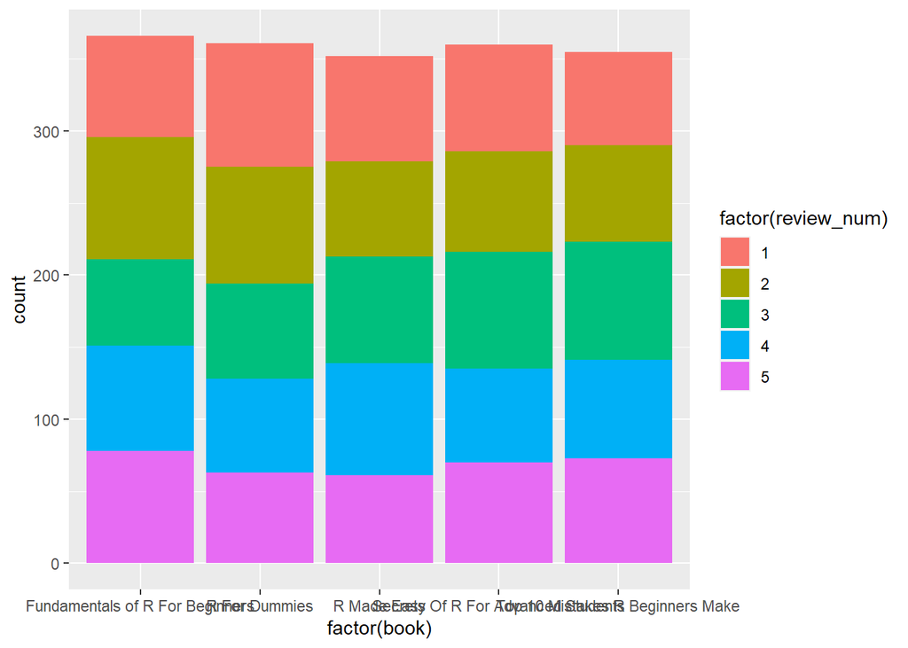

```r
p <- ggplot(data = books,
            mapping = aes(x = factor(book),
            fill = factor(review_num)))
p + geom_bar(position = 'stack', stat = 'count')
```

Según lo obserbado, la evaluacion de los libros es bastante similar en todos los libros y en todos los niveles de puntaucion, por lo tanto no podemos usar el review como un dato para determinar la rentabilidad.

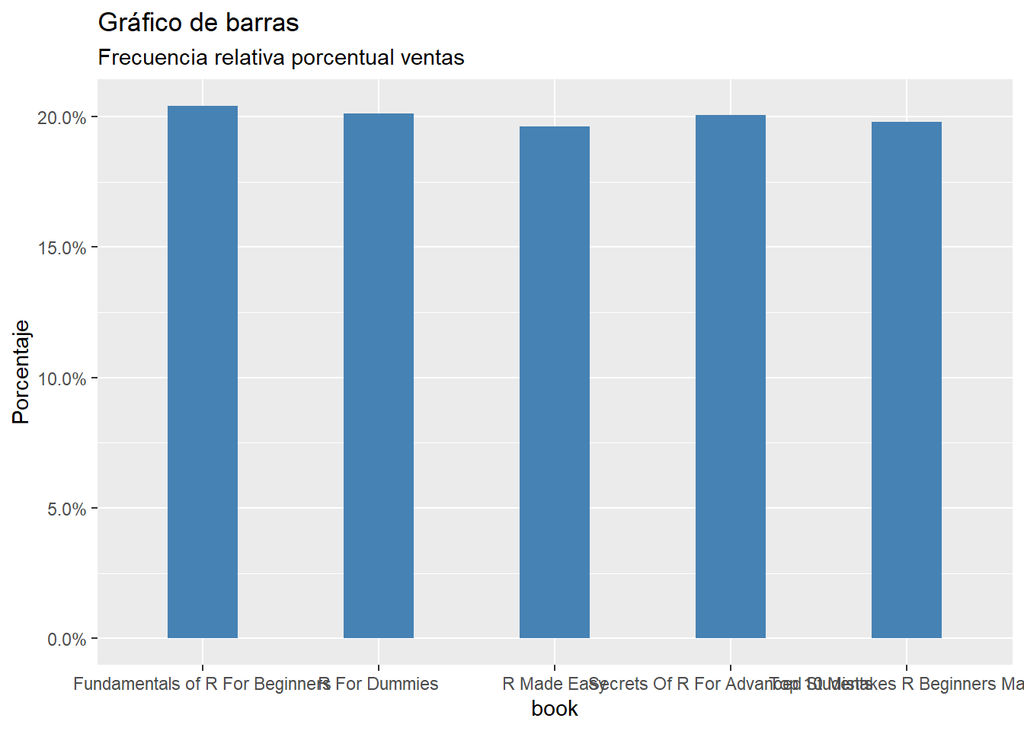

```r
ggplot(data = books,
       aes(x = book, fill = book)) +
  geom_bar(width = 0.4, fill='steelblue', aes(y = (..count..)/sum(..count..))) +
  xlab("book") +
  scale_y_continuous("Porcentaje",labels=scales::percent) +
  labs(title = "Gráfico de barras ",
  subtitle = "Frecuencia relativa porcentual ventas")
```

En los cinco libros se mantiene un porcentaje de ventas muy estrecho bordeando el 20%.

A partir de este grafico podemos concliur que la forma de determinar la mejor rentabilidad es direcamente calculando las ventas por cada libro.

```r
table_price <- books %>%
  group_by(book) %>%
  summarize(Total = sum(price))
table_price
```

```
## # A tibble: 5 x 2
##   book                                Total
##   <chr>                               <dbl>
## 1 Fundamentals of R For Beginners    14636.
## 2 R For Dummies                       5772.
## 3 R Made Easy                         7036.
## 4 Secrets Of R For Advanced Students 18000
## 5 Top 10 Mistakes R Beginners Make   10646.
```

## Conclusión

El libro con mejor rentabilidad es “Secrets Of R For Advanced Students” recaudando 18.000 unidades monetarias.

## EXTRAS

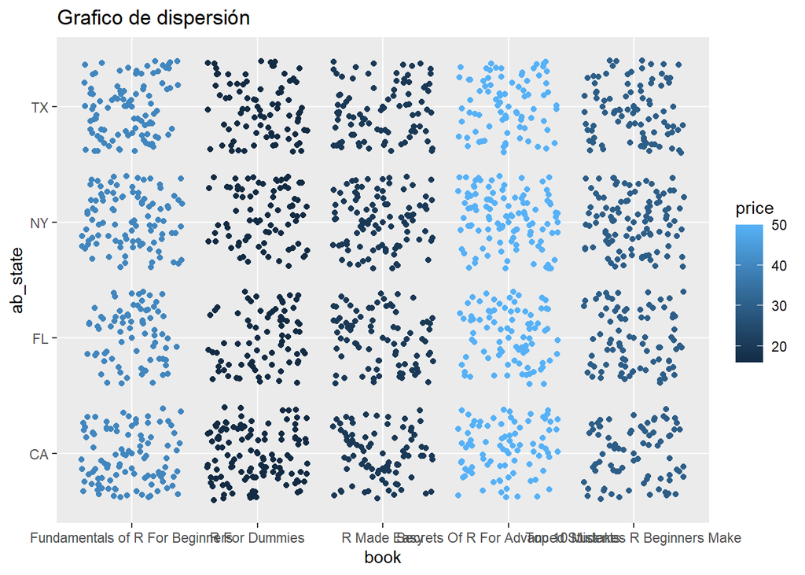

```r
ggplot(data = books,
       aes(x = book, y = ab_state, color=price)) +
  geom_point() +
  geom_jitter()+
  labs(title="Grafico de dispersión")
```

En este grafico vemos la dispersiön de las ventas de libros por estado, observamos que el resultado es muy homogeneo, por lo cual y sumado a lo limitado de los datos, no podemos inferir que un estado es significativamente mejor que otro para las ventas.

### Sin review

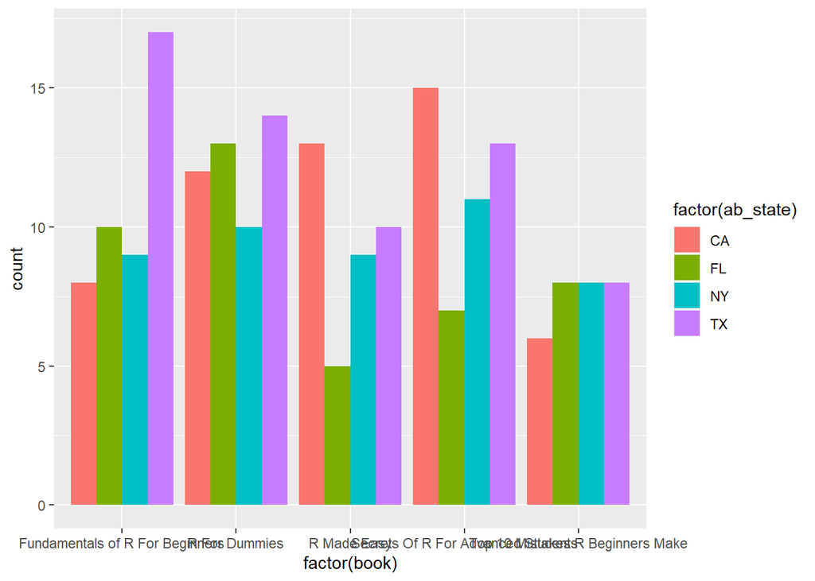

```r
p <- ggplot(data = booksNA,
            mapping = aes(x = factor(book),
            fill = factor(ab_state)))
p + geom_bar(position = 'dodge', stat = 'count')
```

Para mejorar los niveles de review de los clientes, en este grafico notaran los libros que menos review reciben por cada estado.

```r
table_review_T <- filter(books, is_high_review == TRUE)  %>%
  group_by(book) %>%
  summarize(Total_false = sum(is_high_review))
table_review_T
```

```
## # A tibble: 5 x 2
##   book                               Total_false
##   <chr>                                    <int>
## 1 Fundamentals of R For Beginners            151
## 2 R For Dummies                              128
## 3 R Made Easy                                139
## 4 Secrets Of R For Advanced Students         135
## 5 Top 10 Mistakes R Beginners Make           141
```

## PARTE B

```r
sales  <- read_csv("sales2019.csv")
```

Dimension, 5000 registros y 5 columnas

```r
dim(sales)
```

```
## [1] 5000    5
```

Tipo de variables

```r
str(sales)
```

```
## tibble [5,000 x 5] (S3: spec_tbl_df/tbl_df/tbl/data.frame)
##  $ date                 : chr [1:5000] "5/22/19" "11/16/19" "6/27/19" "11/6/19" ...
##  $ user_submitted_review: chr [1:5000] "it was okay" "Awesome!" "Awesome!" "Awesome!" ...
##  $ title                : chr [1:5000] "Secrets Of R For Advanced Students" "R For Dummies" "R For Dummies" "Fundamentals of R For Beginners" ...
##  $ total_purchased      : num [1:5000] 7 3 1 3 NA 1 5 NA 7 1 ...
##  $ customer_type        : chr [1:5000] "Business" "Business" "Individual" "Individual" ...
##  - attr(*, "spec")=
##   .. cols(
##   ..   date = col_character(),
##   ..   user_submitted_review = col_character(),
##   ..   title = col_character(),
##   ..   total_purchased = col_double(),
##   ..   customer_type = col_character()
##   .. )
```

Columnas con valores nulos  
user_submitted_review 885  
total_purchased 718

```r
colSums(is.na(sales))
```

```
##                  date user_submitted_review                 title
##                     0                   885                     0
##       total_purchased         customer_type
##                   718                     0
```

### Depurando total_purchased

```r
sales <- filter(sales, !is.na(user_submitted_review) )
dim(sales)
```

```
## [1] 4115    5
```

Se eliminaron 885 filas con user_submitted_review NA

Buscamos la media de total_purchased, y la aproximaremos para reemplazar NA por un numero entero

```r
media_purchased <- mean( filter(sales, !is.na(total_purchased))$total_purchased)
media_purchased
```

```
## [1] 3.985561
```

Agrego nueva columna asignando total_purchased 4 cuando es NA  
Al crear una nueva columna me facilita comprar los valores antiguos con los nuevos

```r
sales<-sales %>% mutate( total_purchased2 = case_when(
                          is.na(total_purchased) == TRUE ~ 4,
                          TRUE ~ total_purchased
                        )
              )
```

### Depurando user_submitted_review

Identifico los posibles valores

```r
unique(sales$user_submitted_review)
```

```
## [1] "it was okay"
## [2] "Awesome!"
## [3] "Hated it"
## [4] "Never read a better book"
## [5] "OK"
## [6] "The author's other books were better"
## [7] "A lot of material was not needed"
## [8] "Would not recommend"
## [9] "I learned a lot"
```

Creo un vector con las palabras que identifican una buena reseña

```r
positivas <- c("good","great","perfect","awesome","okay","ok","better book","i learned a lot")
```

## NOTA

Esta funcion es buena, puede ser mas rapida y NO necesita mantencion, PERO no funciona al ejecutarla desde el mutate.. entendi el problema pero lo encontre absurdo…

```r
review <- function( string_review ) {
            r <- FALSE
            for (i in 1:length(positivas)){
              if ( str_detect( tolower(string_review), tolower(positivas[c(i)]) ) )
                r <- TRUE
            }
            r
          }
```

Por tanto cree una funcion mas mala, pero que funciona

```r
funcion_mala <- function( string_review ) {
            string_review <- tolower(string_review)
            r <- FALSE
            case_when(
              str_detect(string_review, "good") == TRUE ~ TRUE,
              str_detect(string_review, "great") == TRUE ~ TRUE,
              str_detect(string_review, "awesome") == TRUE ~ TRUE,
              str_detect(string_review, "ok") == TRUE ~ TRUE,
              str_detect(string_review, "okay") == TRUE ~ TRUE,
              str_detect(string_review, "better book") == TRUE ~ TRUE,
              str_detect(string_review, "i learned a lot") == TRUE ~ TRUE,
              TRUE ~ FALSE
            )
          }
```

Y creo la nueva columna

```r
sales<-sales %>% mutate( r_review = funcion_mala( user_submitted_review ) )
```

Cambiando a formato fecha

```r
sales<-sales %>% mutate( date_real = as.Date( date ,format="%m/%d/%y") )
```

Nueva columna para diferenciar antes y despues de la campaña

```r
sales<-sales %>% mutate( after_campaign = case_when(
                          date_real >= "2019-06-01" ~ TRUE,
                          TRUE ~ FALSE
                        )
              )
```

## ANALISIS

```r
sales_ab<- sales  %>%
  group_by(after_campaign) %>%
  summarize(Total = sum(total_purchased2))
sales_ab
```

```
## # A tibble: 2 x 2
##   after_campaign Total
##   <lgl>          <dbl>
## 1 FALSE           6818
## 2 TRUE            9591
```

Efectivamente las ventas aumentaron despues de la campaña.

```r
sales_after <- filter(sales, after_campaign == TRUE)  %>%
  group_by(title) %>%
  summarize(Total_after = sum(total_purchased2))
sales_before <- filter(sales, after_campaign == FALSE)  %>%
  group_by(title) %>%
  summarize(Total_before = sum(total_purchased2))
resume_sales <- merge (sales_before, sales_after, by = "title")

resume_sales
```

```
##                                title Total_before Total_after
## 1    Fundamentals of R For Beginners         2587        3342
## 2                      R For Dummies         2143        3264
## 3                        R Made Easy           12          27
## 4              R vs Python: An Essay         1054        1390
## 5 Secrets Of R For Advanced Students          818        1303
## 6   Top 10 Mistakes R Beginners Make          204         265
```

Aumentaron en todos los titulos siendo “R for dummies” quien lidera la mayor alza de ventas.

### Separacion segun tipo de cliente

```r
sales_after_business <- filter(sales, after_campaign == TRUE & customer_type == "Business" )  %>%
  group_by(title) %>%
  summarize(AFTER_BUSINESS = sum(total_purchased2))
sales_after_individual <- filter(sales, after_campaign == TRUE & customer_type == "Individual" )  %>%
  group_by(title) %>%
  summarize(AFTER_INDIVIDUAL = sum(total_purchased2))
sales_before_business <- filter(sales, after_campaign == FALSE & customer_type == "Business")  %>%
  group_by(title) %>%
  summarize(BEFORE_BUSINESS = sum(total_purchased2))
sales_before_individual <- filter(sales, after_campaign == FALSE & customer_type == "Individual")  %>%
  group_by(title) %>%
  summarize(BEFORE_INDIVIDUAL = sum(total_purchased2))
resume_sales_1 <- merge (sales_after_business, sales_after_individual, by = "title")
resume_sales_2 <- merge (sales_before_business, sales_before_individual  , by = "title")
```

Contruyendo tabla resumen PERSONAS VS EMPRESAS

```r
resume_sales_type = merge (resume_sales_2, resume_sales_1  , by = "title")

resume_sales_type
```

```
##                                title BEFORE_BUSINESS BEFORE_INDIVIDUAL
## 1    Fundamentals of R For Beginners            1821               766
## 2                      R For Dummies            1419               724
## 3              R vs Python: An Essay             718               336
## 4 Secrets Of R For Advanced Students             585               233
## 5   Top 10 Mistakes R Beginners Make             135                69
##   AFTER_BUSINESS AFTER_INDIVIDUAL
## 1           2281             1061
## 2           2328              936
## 3            982              408
## 4            859              444
## 5            213               52
```

Como se puede observar en la tabla, todos los libros aumentaron sus ventas tanto como Business como Individual, siendo la excepcion el titulo “Top 10 Mistakes R Beginners Make” que aumento sus ventas para Business, pero las disminuyo para Individual.

## Antes y despues de review

```r
review_after <- filter(sales, after_campaign == TRUE)  %>%
  group_by(title) %>%
  summarize(after_true = sum(r_review == TRUE))
review_before <- filter(sales, after_campaign == FALSE)  %>%
  group_by(title) %>%
  summarize(Total_before = sum(r_review == TRUE))
resume_review <- merge (review_before, review_after, by = "title")

resume_review
```

```
##                                title Total_before after_true
## 1    Fundamentals of R For Beginners          432        554
## 2                      R For Dummies          364        527
## 3                        R Made Easy            2          5
## 4              R vs Python: An Essay          182        241
## 5 Secrets Of R For Advanced Students          139        207
## 6   Top 10 Mistakes R Beginners Make           27         47
```

Segun lo analisado todos los titulos aumentaros sus review positivos.

### analisando los review negativos

```r
review_after_n <- filter(sales, after_campaign == TRUE)  %>%
  group_by(title) %>%
  summarize(Total_after_n = sum(r_review == FALSE))
review_before_n <- filter(sales, after_campaign == FALSE)  %>%
  group_by(title) %>%
  summarize(Total_before_n = sum(r_review == FALSE))
resume_review <- merge (review_before_n, review_after_n, by = "title")
resume_review
```

```
##                                title Total_before_n Total_after_n
## 1    Fundamentals of R For Beginners            214           295
## 2                      R For Dummies            183           274
## 3                        R Made Easy              1             1
## 4              R vs Python: An Essay             66           123
## 5 Secrets Of R For Advanced Students             73           113
## 6   Top 10 Mistakes R Beginners Make             24            21
```

Segun esta ultima tabla, tambien aumentaron los review negativos en casi todos los titulos, siendo el titulo “Top 10 Mistakes R Beginners Make” la excepcion.

Por tanto, podemos deducir que el aumento en las valoraciones positiva de los titulos no es a concecuencia de una mejor campaña. porque para ambos casos (review positivos y negativos) se registraron importantes aumentos debido al aumento de las mismas ventas.

### Analisando las ventas por mes

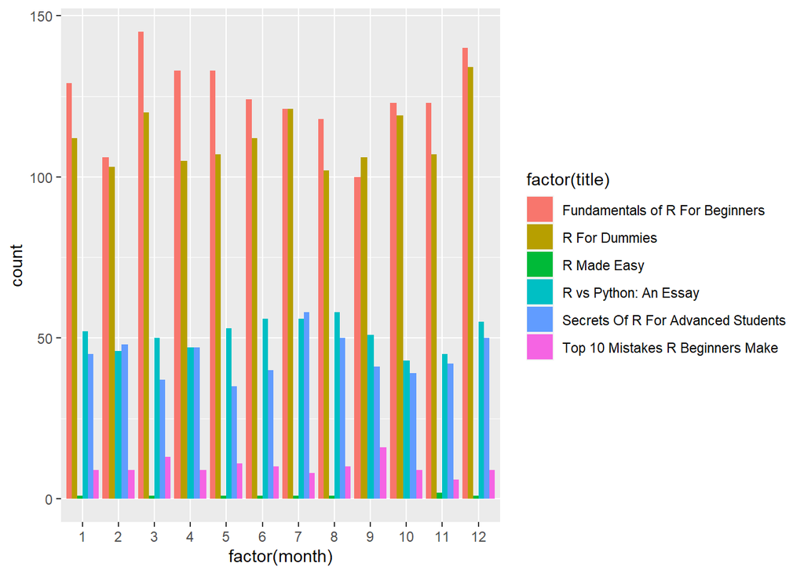

```r
sales<-sales %>% mutate( month = as.numeric(format( date_real, '%m')))

p <- ggplot(data = sales,
            mapping = aes(x = factor(month),
            fill = factor(title )))+
            geom_bar(position = 'dodge', stat = 'count')
p
```

Si bien podemos ver que no existen grandes diferencias mes a mes, siempre los titulo “Fundamentals of R For Beginners” y “R for dummues” lideraron las ventas.

Para ser mas detallistar con respecto a las ventas por fechas, podemos analisar la dispersion de estas.

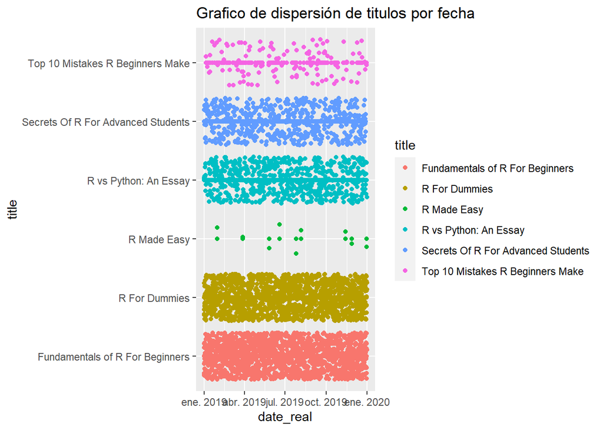

```r
disp <- ggplot(data = sales,
       aes(x = date_real, y = title, color=title)) +
  geom_point() +
  geom_jitter()+
  labs(title="Grafico de dispersión de titulos por fecha")

disp
```

Aca un punto importante no notado anteriormente, es que el titulo “R Made Easy” no registra ventas en algunos meses.